# R Notebook

```r
#librerías necesarias para el proyecto

library(dplyr)
```

```r
library(ggplot2)
library(corrgram)
library(corrplot)
library(outliers)
library(nortest)
library(car)
library(FactoMineR)
library(stats)
library(gridExtra)
library(conflicted)
conflict_prefer("select", "dplyr")
```

```
## [conflicted] Will prefer dplyr::select over any other package
```

```r
#Carga de datos

wineData<-read.csv("C:/Users/Juan/OneDrive/MASTER EN CIENCIA DE DATOS/TIPOLOGÍA Y CICLO DEL DATO/PRACTICA2/winequality-red.csv",sep=";")
```

```r
#Se describen los atributos y el tipo de variable
glimpse(wineData)
```

```
## Observations: 1,599
## Variables: 12
## $ fixed.acidity        <dbl> 7.4, 7.8, 7.8, 11.2, 7.4, 7.4, 7.9, 7.3, ...
## $ volatile.acidity     <dbl> 0.700, 0.880, 0.760, 0.280, 0.700, 0.660,...
## $ citric.acid          <dbl> 0.00, 0.00, 0.04, 0.56, 0.00, 0.00, 0.06,...
## $ residual.sugar       <dbl> 1.9, 2.6, 2.3, 1.9, 1.9, 1.8, 1.6, 1.2, 2...
## $ chlorides            <dbl> 0.076, 0.098, 0.092, 0.075, 0.076, 0.075,...
## $ free.sulfur.dioxide  <dbl> 11, 25, 15, 17, 11, 13, 15, 15, 9, 17, 15...
## $ total.sulfur.dioxide <dbl> 34, 67, 54, 60, 34, 40, 59, 21, 18, 102, ...
## $ density              <dbl> 0.9978, 0.9968, 0.9970, 0.9980, 0.9978, 0...
## $ pH                   <dbl> 3.51, 3.20, 3.26, 3.16, 3.51, 3.51, 3.30,...
## $ sulphates            <dbl> 0.56, 0.68, 0.65, 0.58, 0.56, 0.56, 0.46,...
## $ alcohol              <dbl> 9.4, 9.8, 9.8, 9.8, 9.4, 9.4, 9.4, 10.0, ...
## $ quality              <int> 5, 5, 5, 6, 5, 5, 5, 7, 7, 5, 5, 5, 5, 5,...
```

```r
#Se crea una tabla de contingencia para determinar la cantidad de vinos que están asociados a uno u otra clase.

table(wineData$quality)
```

```
##
##   3   4   5   6   7   8
##  10  53 681 638 199  18
```

```r
summary(wineData)
```

```
##  fixed.acidity   volatile.acidity  citric.acid    residual.sugar
##  Min.   : 4.60   Min.   :0.1200   Min.   :0.000   Min.   : 0.900
##  1st Qu.: 7.10   1st Qu.:0.3900   1st Qu.:0.090   1st Qu.: 1.900
##  Median : 7.90   Median :0.5200   Median :0.260   Median : 2.200
##  Mean   : 8.32   Mean   :0.5278   Mean   :0.271   Mean   : 2.539
##  3rd Qu.: 9.20   3rd Qu.:0.6400   3rd Qu.:0.420   3rd Qu.: 2.600
##  Max.   :15.90   Max.   :1.5800   Max.   :1.000   Max.   :15.500
##    chlorides       free.sulfur.dioxide total.sulfur.dioxide
##  Min.   :0.01200   Min.   : 1.00       Min.   :  6.00
##  1st Qu.:0.07000   1st Qu.: 7.00       1st Qu.: 22.00
##  Median :0.07900   Median :14.00       Median : 38.00
##  Mean   :0.08747   Mean   :15.87       Mean   : 46.47
##  3rd Qu.:0.09000   3rd Qu.:21.00       3rd Qu.: 62.00
##  Max.   :0.61100   Max.   :72.00       Max.   :289.00
##     density             pH          sulphates         alcohol
##  Min.   :0.9901   Min.   :2.740   Min.   :0.3300   Min.   : 8.40
##  1st Qu.:0.9956   1st Qu.:3.210   1st Qu.:0.5500   1st Qu.: 9.50
##  Median :0.9968   Median :3.310   Median :0.6200   Median :10.20
##  Mean   :0.9967   Mean   :3.311   Mean   :0.6581   Mean   :10.42
##  3rd Qu.:0.9978   3rd Qu.:3.400   3rd Qu.:0.7300   3rd Qu.:11.10
##  Max.   :1.0037   Max.   :4.010   Max.   :2.0000   Max.   :14.90
##     quality
##  Min.   :3.000
##  1st Qu.:5.000
##  Median :6.000
##  Mean   :5.636
##  3rd Qu.:6.000
##  Max.   :8.000
```

ANÁLISIS PARA LA DETERMINACIÓN DE VALORES ATÍPICOS

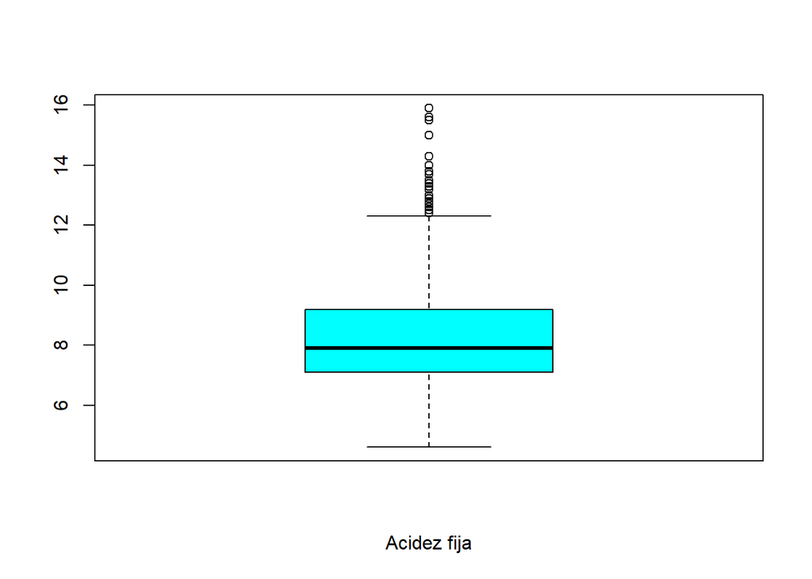

```r
boxplot(wineData$fixed.acidity, xlab="Acidez fija", col="cyan")
```

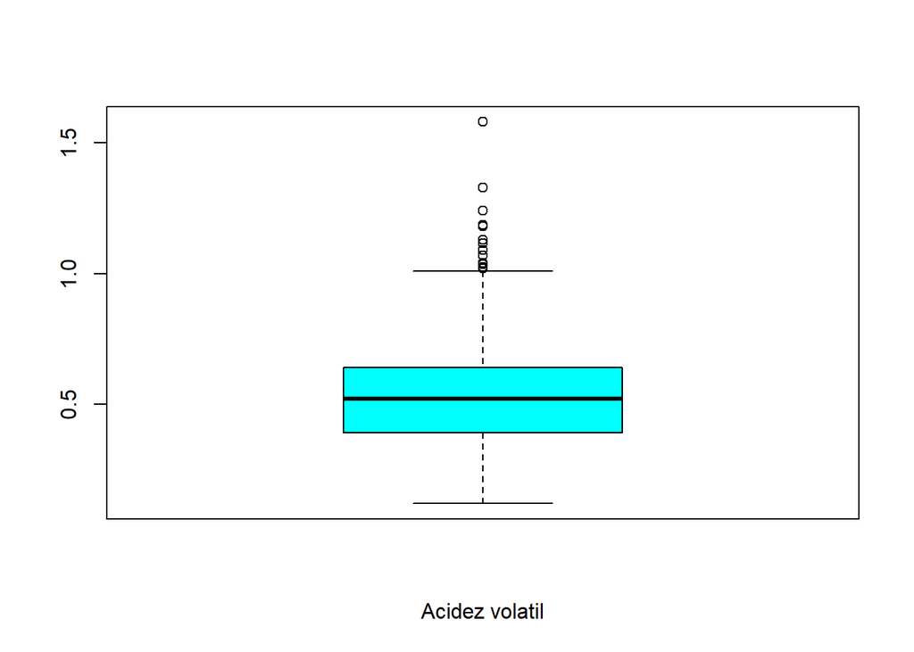

```r
boxplot(wineData$volatile.acidity, xlab="Acidez volatil", col="cyan")
```

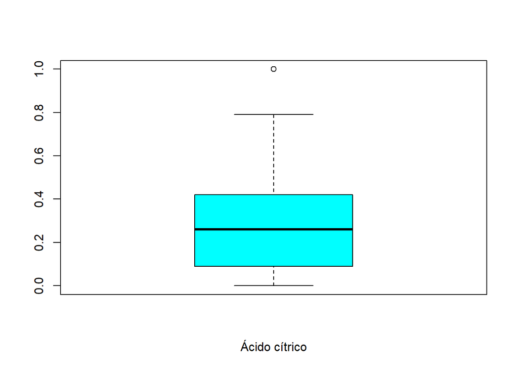

```r
boxplot(wineData$citric.acid, xlab="Ácido cítrico", col="cyan")
```

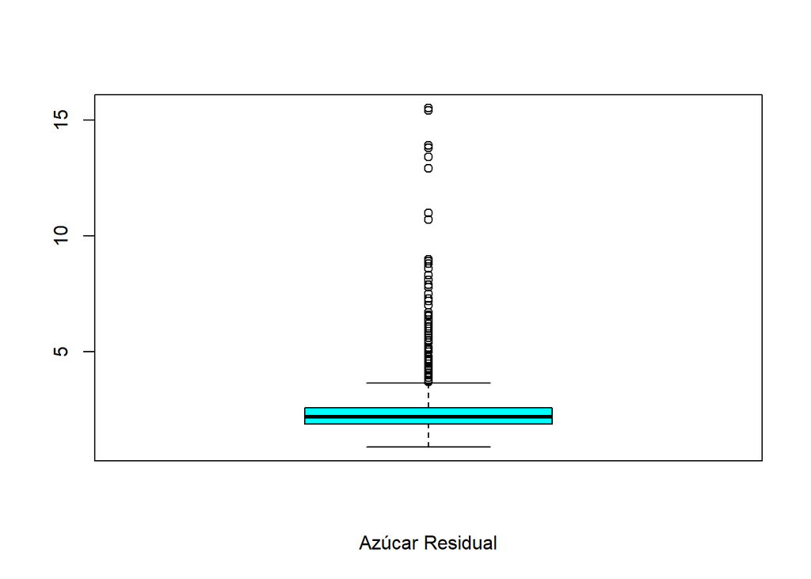

```r
boxplot(wineData$residual.sugar, xlab="Azúcar Residual", col="cyan")
```

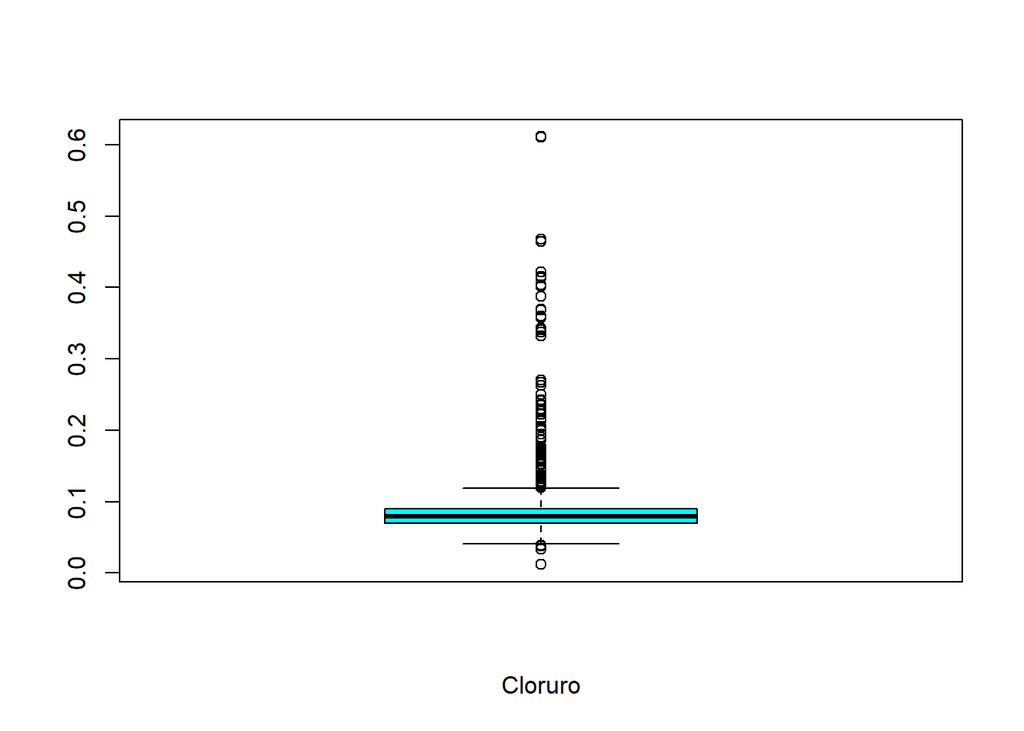

```r
boxplot(wineData$chlorides, xlab="Cloruro", col="cyan")
```

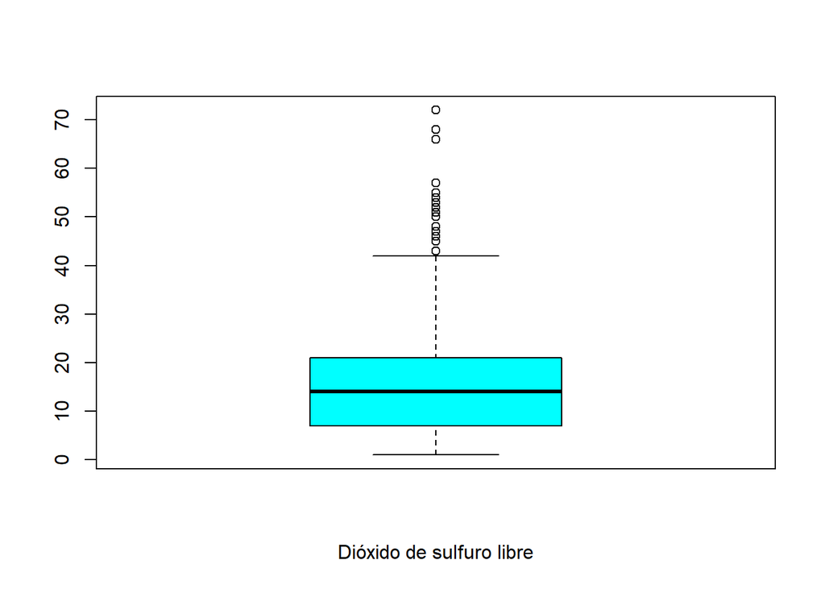

```r
boxplot(wineData$free.sulfur.dioxide, xlab="Dióxido de sulfuro libre", col="cyan")
```

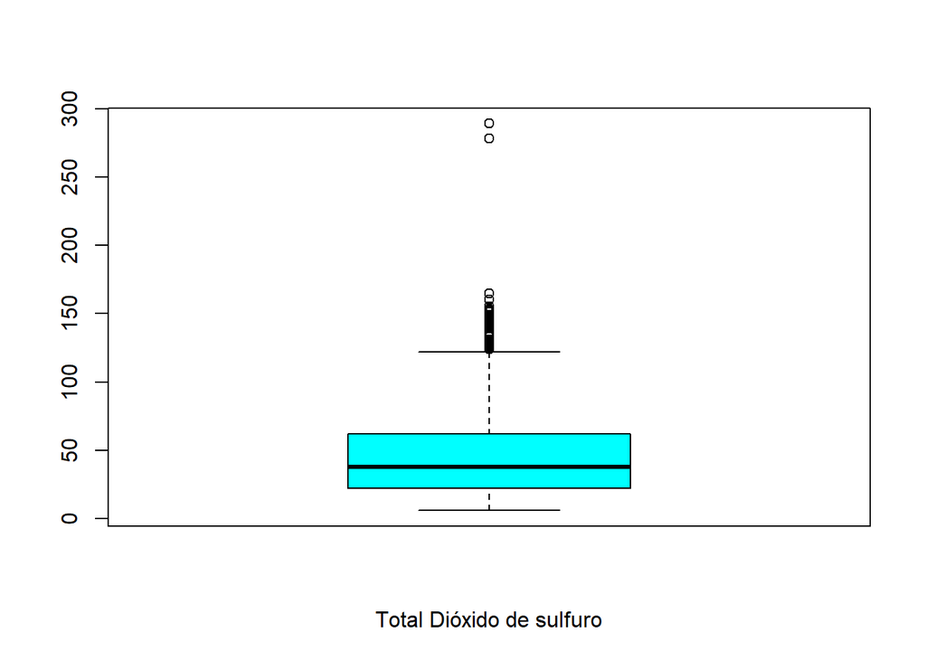

```r
boxplot(wineData$total.sulfur.dioxide, xlab="Total Dióxido de sulfuro", col="cyan")
```

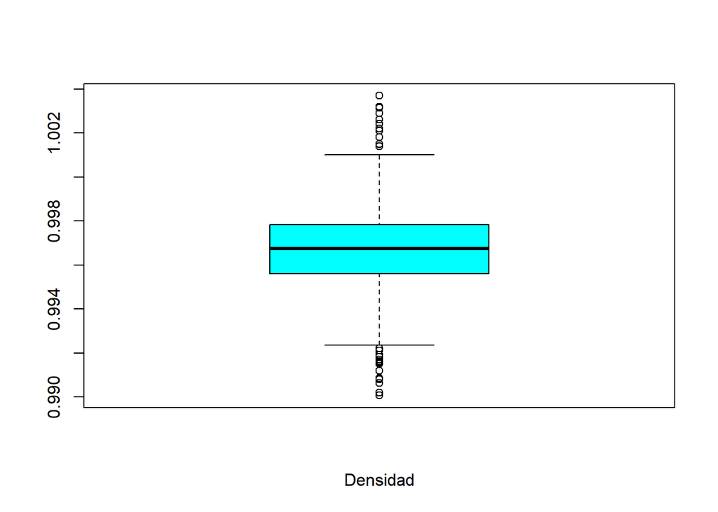

```r
boxplot(wineData$density, xlab="Densidad", col="cyan")
```

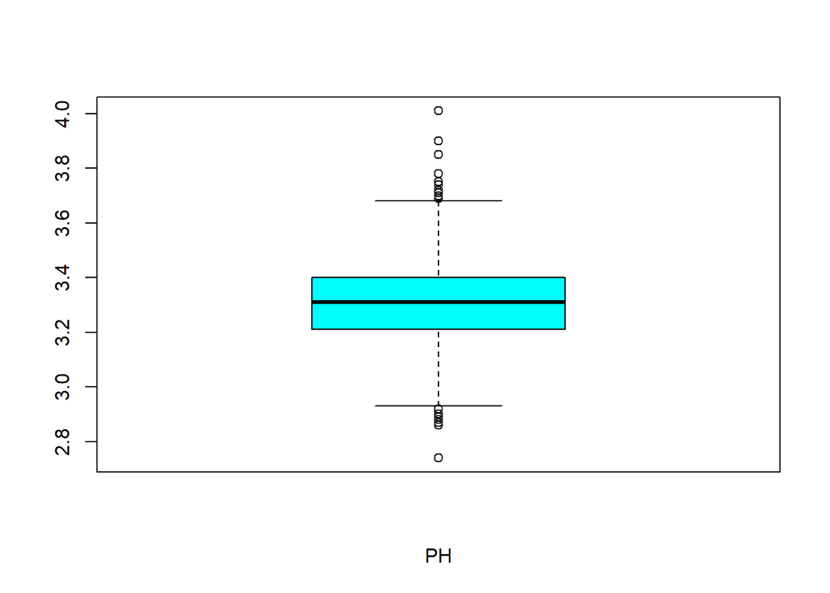

```r
boxplot(wineData$pH, xlab="PH", col="cyan")
```

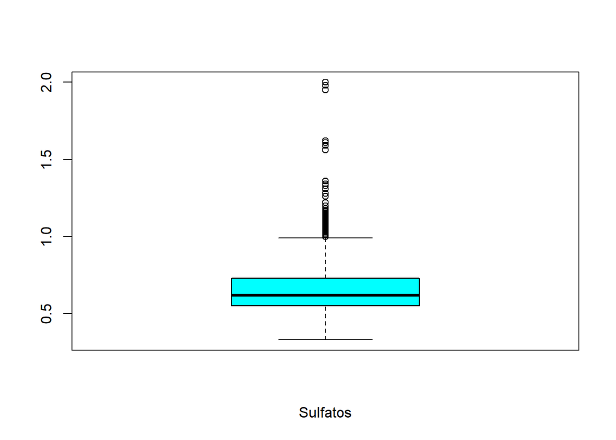

```r
boxplot(wineData$sulphates, xlab="Sulfatos", col="cyan")
```

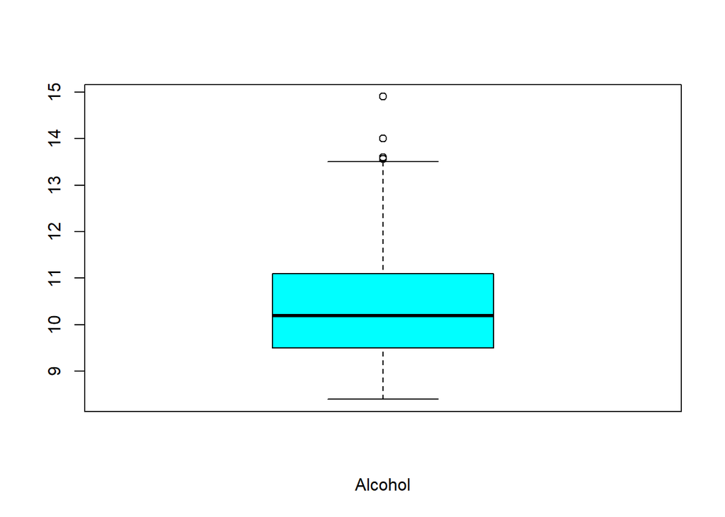

```r
boxplot(wineData$alcohol, xlab="Alcohol", col="cyan")
```

ANÁLISIS PARA DETERMINAR LA IMPORTANCIA DE LA COMPOSICIÓN QUÍMICA EN FUNCIÓN DE LA CALIDAD DEL VINO.

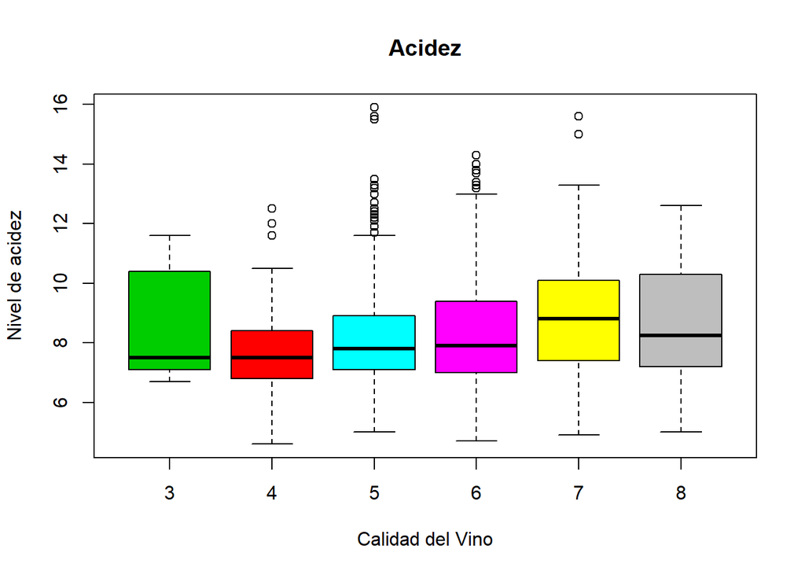

```r
boxplot(wineData$fixed.acidity~wineData$quality, main="Acidez",xlab="Calidad del Vino", ylab="Nivel de acidez", col=c(123,138,125,126,127,128))
```

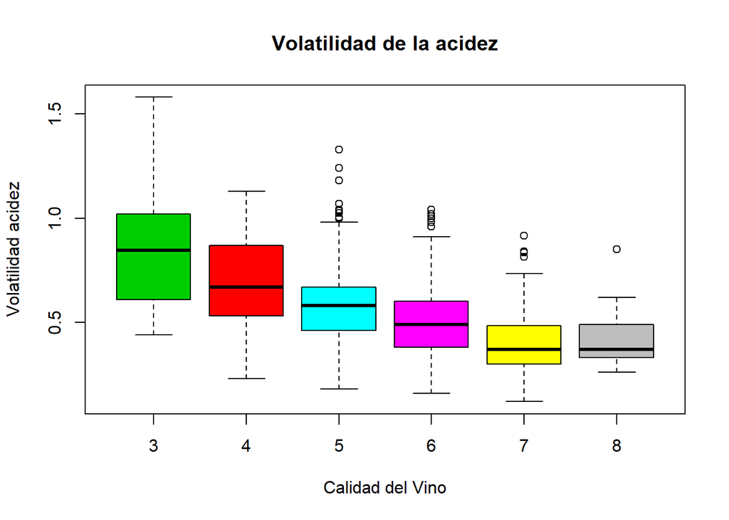

```r
boxplot(wineData$volatile.acidity~wineData$quality, main="Volatilidad de la acidez",xlab="Calidad del Vino", ylab="Volatilidad acidez", col=c(123,138,125,126,127,128))
```

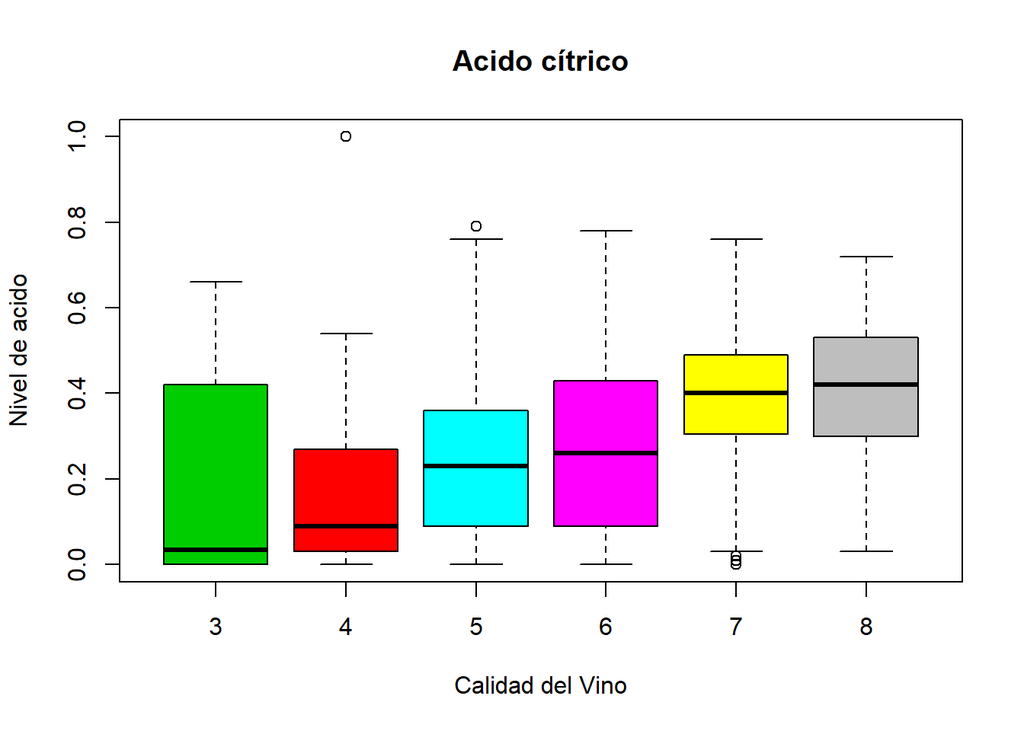

```r
boxplot(wineData$citric.acid~wineData$quality, main="Acido cítrico",xlab="Calidad del Vino", ylab="Nivel de acido", col=c(123,138,125,126,127,128))
```

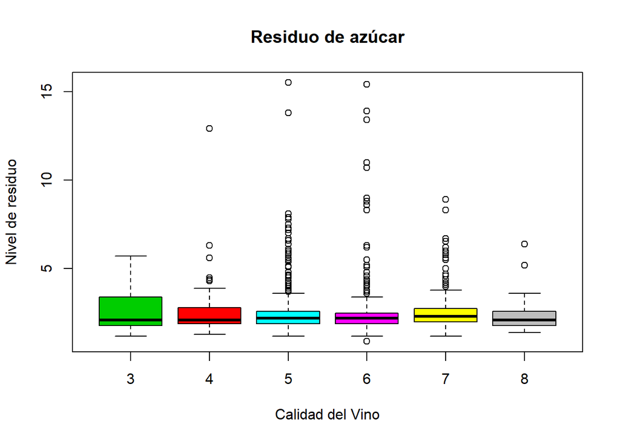

```r
boxplot(wineData$residual.sugar~wineData$quality, main="Residuo de azúcar",xlab="Calidad del Vino", ylab="Nivel de residuo", col=c(123,138,125,126,127,128))
```

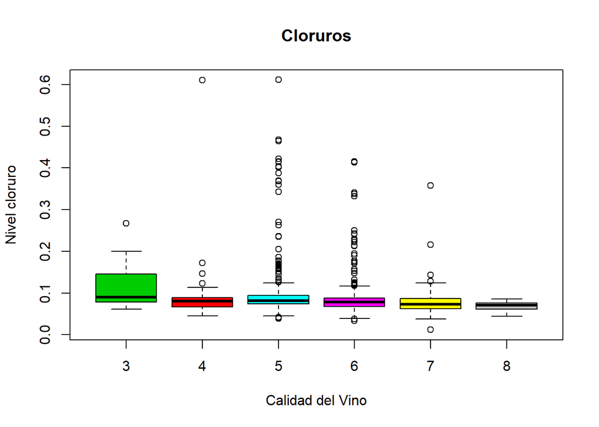

```r
boxplot(wineData$chlorides~wineData$quality, main="Cloruros",xlab="Calidad del Vino", ylab="Nivel cloruro", col=c(123,138,125,126,127,128))
```

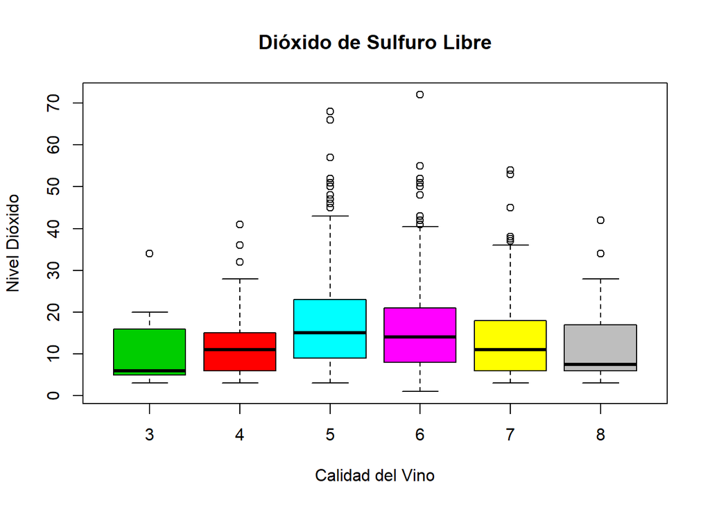

```r
boxplot(wineData$free.sulfur.dioxide~wineData$quality, main="Dióxido de Sulfuro Libre",xlab="Calidad del Vino", ylab="Nivel Dióxido", col=c(123,138,125,126,127,128))
```

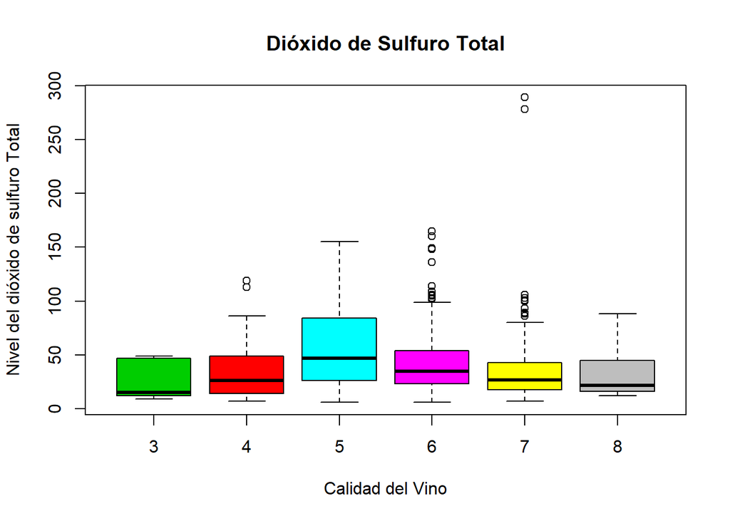

```r
boxplot(wineData$total.sulfur.dioxide~wineData$quality, main="Dióxido de Sulfuro Total",xlab="Calidad del Vino", ylab="Nivel del dióxido de sulfuro Total", col=c(123,138,125,126,127,128))
```

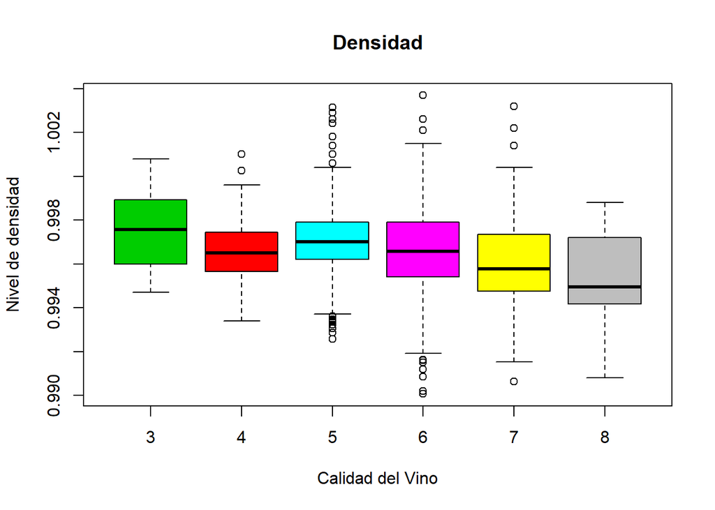

```r
boxplot(wineData$density~wineData$quality, main="Densidad",xlab="Calidad del Vino", ylab="Nivel de densidad", col=c(123,138,125,126,127,128))
```

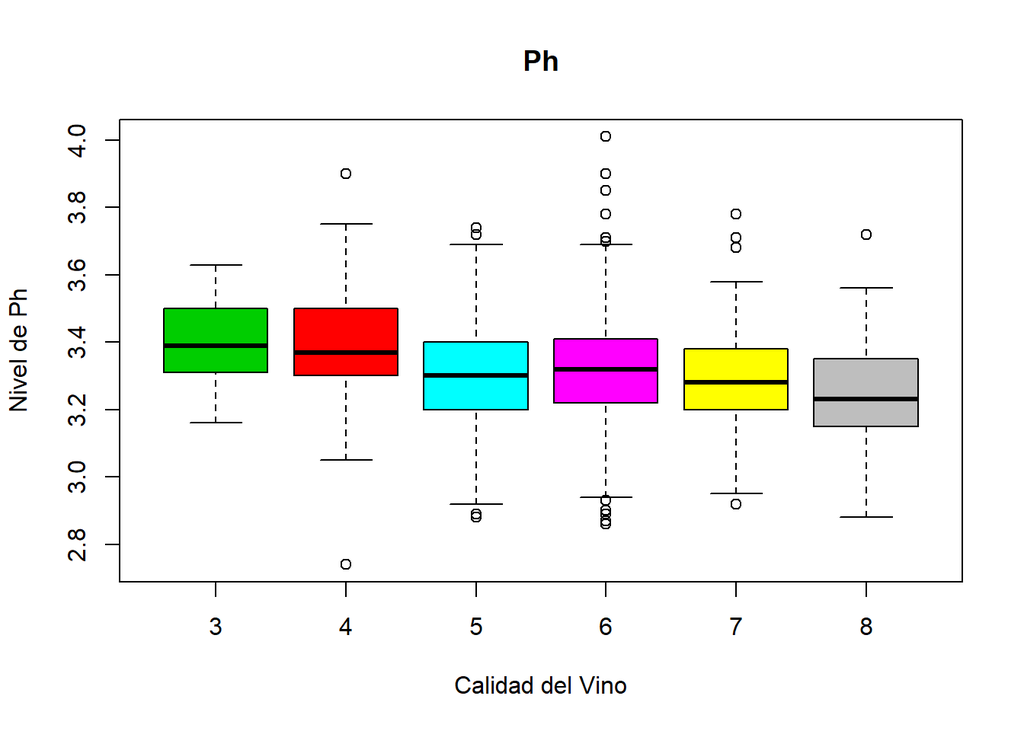

```r
boxplot(wineData$pH~wineData$quality, main="Ph",xlab="Calidad del Vino", ylab="Nivel de Ph", col=c(123,138,125,126,127,128))
```

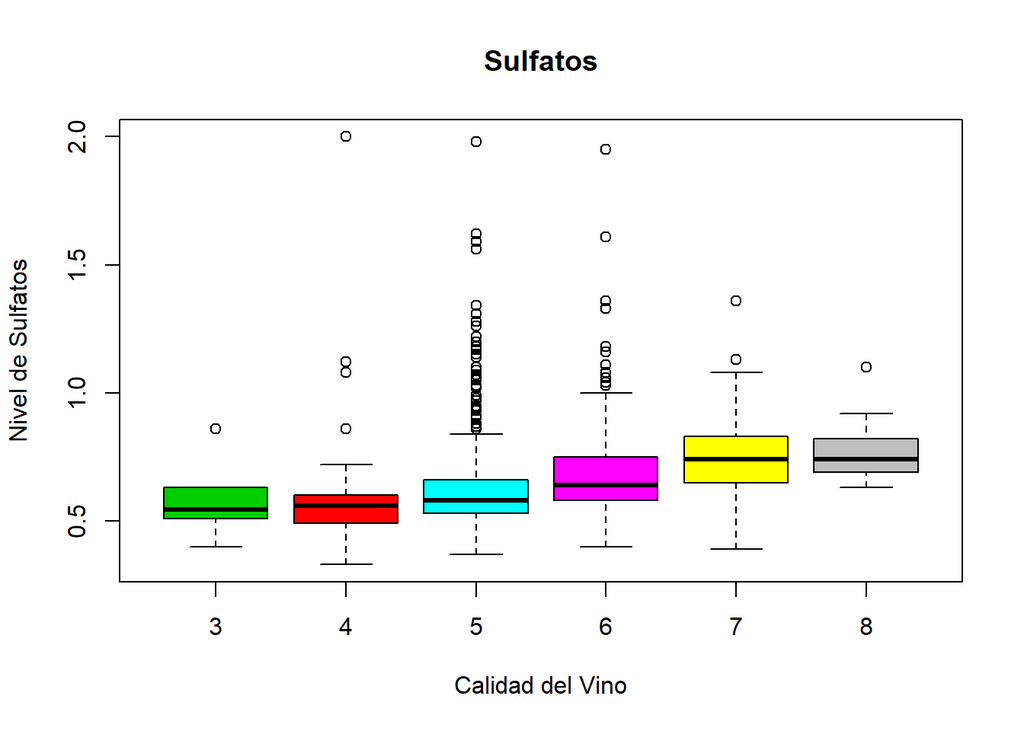

```r
boxplot(wineData$sulphates~wineData$quality, main="Sulfatos",xlab="Calidad del Vino", ylab="Nivel de Sulfatos", col=c(123,138,125,126,127,128))
```

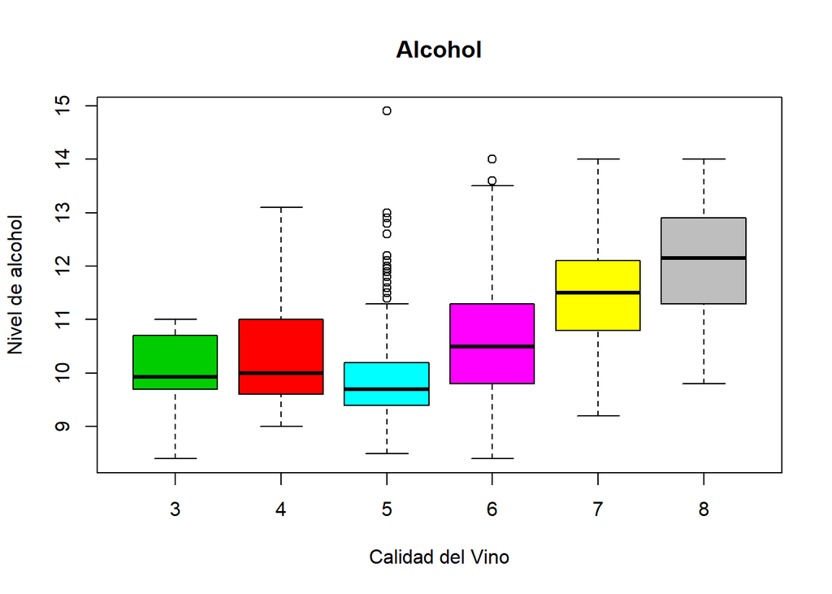

```r
boxplot(wineData$alcohol~wineData$quality, main="Alcohol",xlab="Calidad del Vino", ylab="Nivel de alcohol", col=c(123,138,125,126,127,128))
```

ANÁLISIS PARA DETERMINAR LA CORRELACIÓN ENTRE LAS DIFERENTES VARIABLES.

[figure not shown]

```r
corrgram(x=cor(wineData))
```

```r
R = cor(wineData[, 1:12])
round(R, 3)
```

```
##                      fixed.acidity volatile.acidity citric.acid
## fixed.acidity                1.000           -0.256       0.672
## volatile.acidity            -0.256            1.000      -0.552
## citric.acid                  0.672           -0.552       1.000
## residual.sugar               0.115            0.002       0.144
## chlorides                    0.094            0.061       0.204
## free.sulfur.dioxide         -0.154           -0.011      -0.061
## total.sulfur.dioxide        -0.113            0.076       0.036
## density                      0.668            0.022       0.365
## pH                          -0.683            0.235      -0.542
## sulphates                    0.183           -0.261       0.313
## alcohol                     -0.062           -0.202       0.110
## quality                      0.124           -0.391       0.226
##                      residual.sugar chlorides free.sulfur.dioxide
## fixed.acidity                 0.115     0.094              -0.154
## volatile.acidity              0.002     0.061              -0.011
## citric.acid                   0.144     0.204              -0.061
## residual.sugar                1.000     0.056               0.187
## chlorides                     0.056     1.000               0.006
## free.sulfur.dioxide           0.187     0.006               1.000
## total.sulfur.dioxide          0.203     0.047               0.668
## density                       0.355     0.201              -0.022
## pH                           -0.086    -0.265               0.070
## sulphates                     0.006     0.371               0.052
## alcohol                       0.042    -0.221              -0.069
## quality                       0.014    -0.129              -0.051
##                      total.sulfur.dioxide density     pH sulphates alcohol
## fixed.acidity                      -0.113   0.668 -0.683     0.183  -0.062
## volatile.acidity                    0.076   0.022  0.235    -0.261  -0.202
## citric.acid                         0.036   0.365 -0.542     0.313   0.110
## residual.sugar                      0.203   0.355 -0.086     0.006   0.042
## chlorides                           0.047   0.201 -0.265     0.371  -0.221
## free.sulfur.dioxide                 0.668  -0.022  0.070     0.052  -0.069
## total.sulfur.dioxide                1.000   0.071 -0.066     0.043  -0.206
## density                             0.071   1.000 -0.342     0.149  -0.496
## pH                                 -0.066  -0.342  1.000    -0.197   0.206
## sulphates                           0.043   0.149 -0.197     1.000   0.094
## alcohol                            -0.206  -0.496  0.206     0.094   1.000
## quality                            -0.185  -0.175 -0.058     0.251   0.476
##                      quality
## fixed.acidity          0.124
## volatile.acidity      -0.391
## citric.acid            0.226
## residual.sugar         0.014
## chlorides             -0.129
## free.sulfur.dioxide   -0.051
## total.sulfur.dioxide  -0.185
## density               -0.175
## pH                    -0.058
## sulphates              0.251
## alcohol                0.476
## quality                1.000
```

ANALISIS SI LA DISTRIBUCIÓN PRESENTA NORMALIDAD

A pesar de que continuamente se alude al test Kolmogorov-Smirnov como un test válido para contrastar la normalidad, esto no es del todo cierto. El Kolmogorov-Smirnov asume que se conoce la media y varianza poblacional, lo que en la mayoría de los casos no es posible. Esto hace que el test sea muy conservador y poco potente. Para solventar este problema, se desarrolló una modificación del Kolmogorov-Smirnov conocida como test Lilliefors. El test Lilliefors asume que la media y varianza son desconocidas, estando especialmente desarrollado para contrastar la normalidad. Es la alternativa al test de Shapiro-Wilk cuando el número de observaciones es mayor de 50

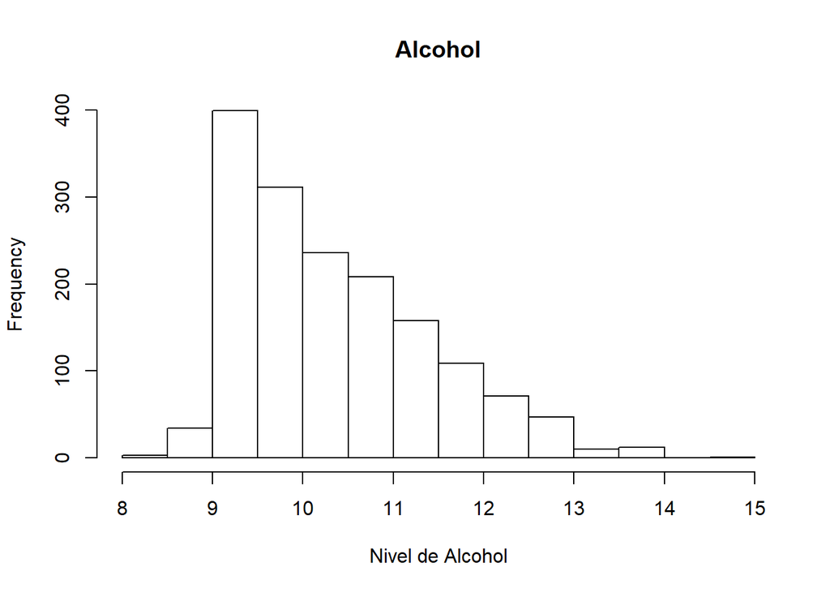

```r
hist(wineData[,11],main="Alcohol", xlab="Nivel de Alcohol")
```

```r
shapiro.test(wineData$alcohol)
```

```
##
##  Shapiro-Wilk normality test
##
## data:  wineData$alcohol
## W = 0.92884, p-value < 2.2e-16
```

```r
lillie.test(x = wineData$alcohol)
```

```
##
##  Lilliefors (Kolmogorov-Smirnov) normality test
##
## data:  wineData$alcohol
## D = 0.12145, p-value < 2.2e-16
```

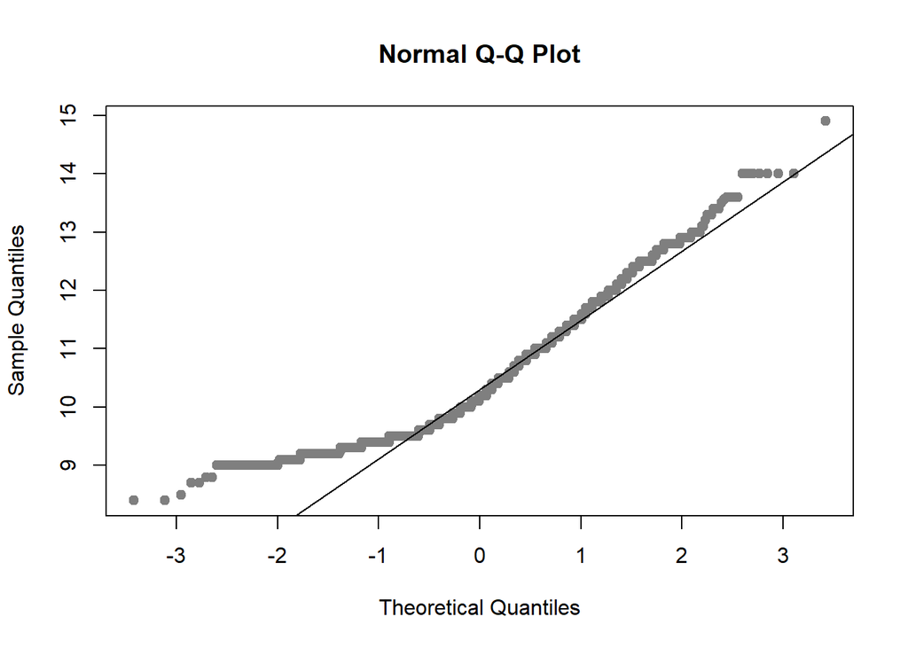

```r
qqnorm(wineData$alcohol, pch = 19, col = "gray50")
qqline(wineData$alcohol)
```

Tal y como se puede apreciar, la distribución del alcohol no es una distribución normal, podemos confirmalo aplicando el test de shapiro-wilk en el que el p-valor es inferior a 0.05 y portanto se descarta la hipótesis nula y por tanto la distribución no es normal.

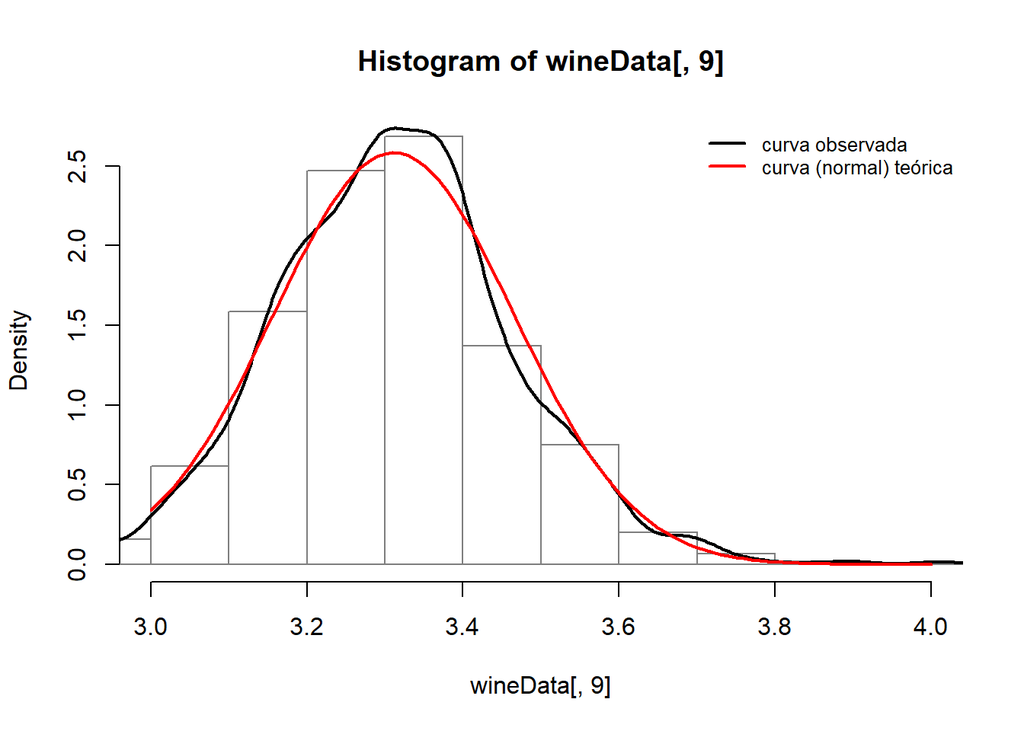

```r
hist(wineData[,9], freq = F, xlim = c(3, 4), border = "gray50")
lines(density(wineData[,9]), ylim = c(0, 0.8), xlim = c(3, 7), lwd = 2)
curve(dnorm(x, mean(wineData[,9]), sd(wineData[,9])), lwd = 2, col = "red", add = T)
legend("topright", c("curva observada", "curva (normal) teórica"),
       lty = 1, lwd = 2, col = c("black", "red"), bty = "n",
       cex = 0.8)
```

```r
shapiro.test(wineData$pH)
```

```
##
##  Shapiro-Wilk normality test
##
## data:  wineData$pH
## W = 0.99349, p-value = 1.712e-06
```

```r
lillie.test(x = wineData$pH)
```

```
##
##  Lilliefors (Kolmogorov-Smirnov) normality test
##
## data:  wineData$pH
## D = 0.040368, p-value = 2.244e-06
```

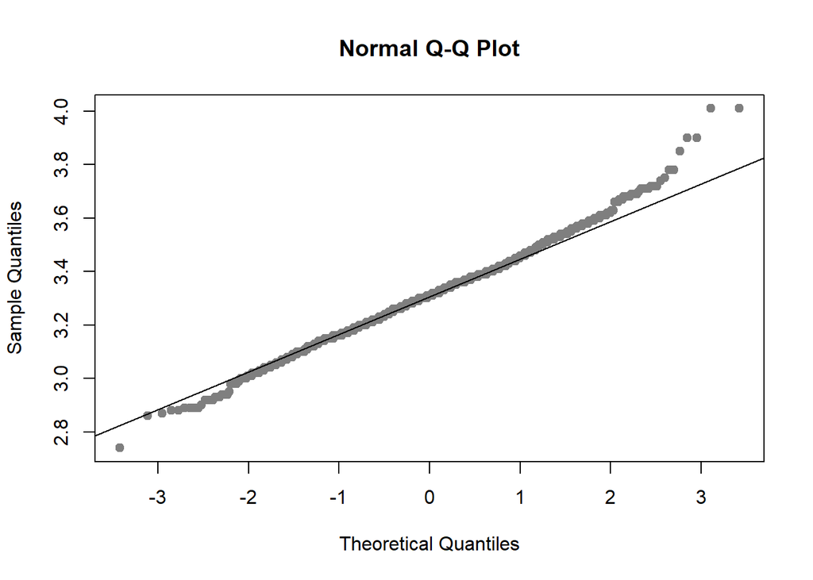

```r
qqnorm(wineData$pH, pch = 19, col = "gray50")
qqline(wineData$pH)
```

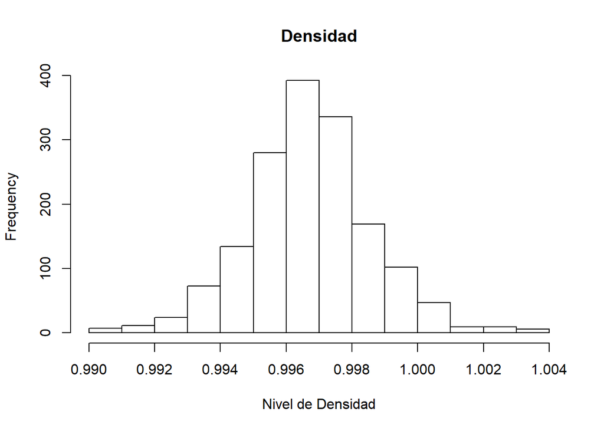

```r
hist(wineData[,8],main="Densidad", xlab="Nivel de Densidad")
```

```r
shapiro.test(wineData$density)
```

```
##
##  Shapiro-Wilk normality test
##
## data:  wineData$density
## W = 0.99087, p-value = 1.936e-08
```

```r
lillie.test(x = wineData$density)
```

```
##
##  Lilliefors (Kolmogorov-Smirnov) normality test
##
## data:  wineData$density
## D = 0.044787, p-value = 6.252e-08
```

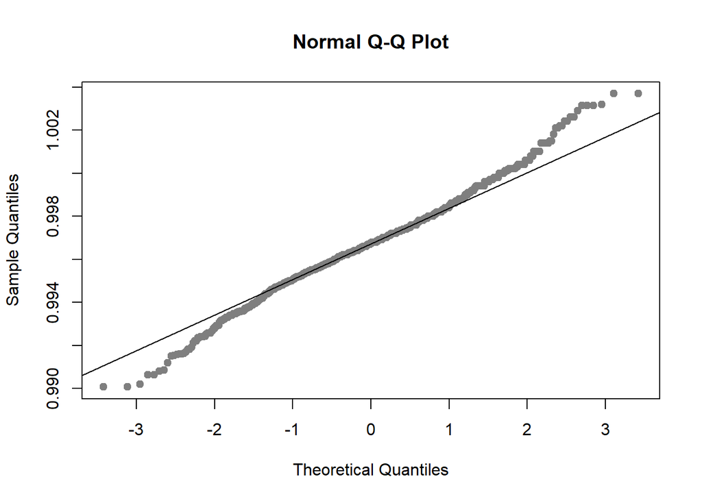

```r
qqnorm(wineData$density, pch = 19, col = "gray50")
qqline(wineData$density)
```

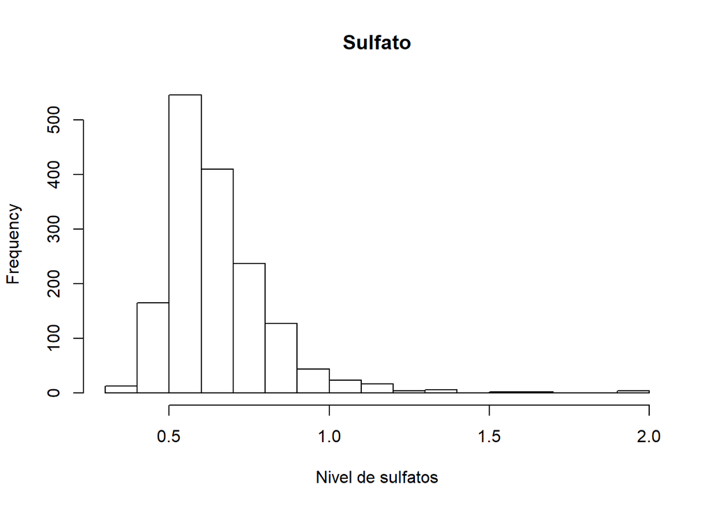

```r
hist(wineData[,10],main="Sulfato", xlab="Nivel de sulfatos")
```

```r
shapiro.test(wineData$sulphates)
```

```
##
##  Shapiro-Wilk normality test
##
## data:  wineData$sulphates
## W = 0.83304, p-value < 2.2e-16
```

```r
lillie.test(x = wineData$sulphates)
```

```
##
##  Lilliefors (Kolmogorov-Smirnov) normality test
##
## data:  wineData$sulphates
## D = 0.12479, p-value < 2.2e-16
```

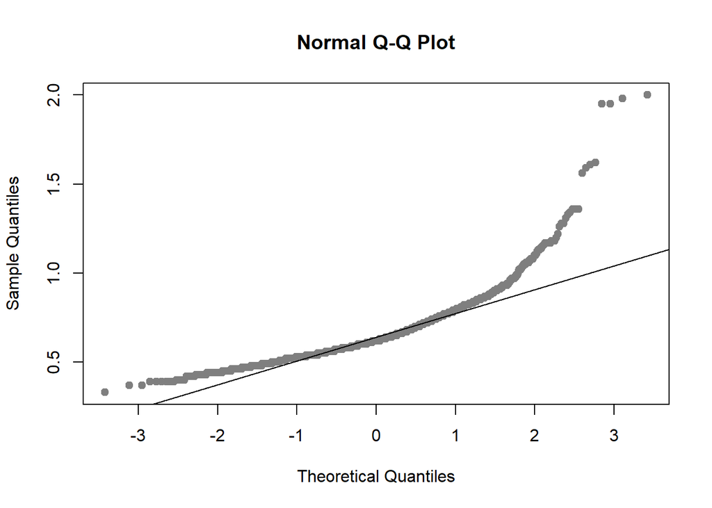

```r
qqnorm(wineData$sulphates, pch = 19, col = "gray50")
qqline(wineData$sulphates)
```

ANÁLISIS DE LA HOMOGENEIDAD DE LA VARIANZA

```r
leveneTest(c(wineData$alcohol,wineData$pH,wineData$density,wineData$sulphates),rep(c("Gr1","Gr2","Gr3","Gr4"), each=1599), center="median")
```

|  | Df | F value | Pr(>F) |
| --- | --- | --- | --- |
| group | 3 | 2107.702 | 0 |
|  | 6392 | NA | NA |

ANÁLISIS DE LOS DATOS

Generamos el modelo.

```r
modelo<-lm(quality~volatile.acidity+citric.acid+density+pH+sulphates+alcohol, data=wineData)
```

```r
summary(modelo)
```

```
##
## Call:
## lm(formula = quality ~ volatile.acidity + citric.acid + density +
##     pH + sulphates + alcohol, data = wineData)
##
## Residuals:
##      Min       1Q   Median       3Q      Max
## -2.64141 -0.38701 -0.06721  0.45480  2.11572
##
## Coefficients:
##                   Estimate Std. Error t value Pr(>|t|)
## (Intercept)      -11.77058   11.92162  -0.987 0.323631
## volatile.acidity  -1.32197    0.11597 -11.399  < 2e-16 ***
## citric.acid       -0.37834    0.13479  -2.807 0.005064 **
## density           15.84518   11.88503   1.333 0.182655
## pH                -0.47787    0.13381  -3.571 0.000366 ***
## sulphates          0.65627    0.10367   6.330 3.17e-10 ***
## alcohol            0.34190    0.01985  17.222  < 2e-16 ***
## ---
## Signif. codes:  0 '***' 0.001 '**' 0.01 '*' 0.05 '.' 0.1 ' ' 1
##
## Residual standard error: 0.6563 on 1592 degrees of freedom
## Multiple R-squared:  0.3421, Adjusted R-squared:  0.3396
## F-statistic:   138 on 6 and 1592 DF,  p-value: < 2.2e-16
```

Se elimina la densidad del modelo

```r
modelo<-lm(quality~volatile.acidity+citric.acid+pH+sulphates+alcohol, data=wineData)
```

```r
summary(modelo)
```

```
##
## Call:
## lm(formula = quality ~ volatile.acidity + citric.acid + pH +
##     sulphates + alcohol, data = wineData)
##
## Residuals:
##      Min       1Q   Median       3Q      Max
## -2.63642 -0.37783 -0.07067  0.46233  2.10817
##
## Coefficients:
##                  Estimate Std. Error t value Pr(>|t|)
## (Intercept)       4.11161    0.45915   8.955  < 2e-16 ***
## volatile.acidity -1.28363    0.11238 -11.422  < 2e-16 ***
## citric.acid      -0.29730    0.12034  -2.471   0.0136 *
## pH               -0.47476    0.13382  -3.548   0.0004 ***
## sulphates         0.67306    0.10293   6.539 8.31e-11 ***
## alcohol           0.32731    0.01657  19.756  < 2e-16 ***
## ---
## Signif. codes:  0 '***' 0.001 '**' 0.01 '*' 0.05 '.' 0.1 ' ' 1
##
## Residual standard error: 0.6564 on 1593 degrees of freedom
## Multiple R-squared:  0.3413, Adjusted R-squared:  0.3393
## F-statistic: 165.1 on 5 and 1593 DF,  p-value: < 2.2e-16
```

Vamos a calcular la regresión estandarizando

```r
wineDataStd<-data.frame(scale(wineData))
```

```r
modelo_standard<-lm(quality~volatile.acidity+citric.acid+pH+sulphates+alcohol, data=wineDataStd)
```

```r
summary(modelo_standard)
```

```
##
## Call:
## lm(formula = quality ~ volatile.acidity + citric.acid + pH +
##     sulphates + alcohol, data = wineDataStd)
##
## Residuals:
##     Min      1Q  Median      3Q     Max
## -3.2646 -0.4679 -0.0875  0.5725  2.6105
##
## Coefficients:
##                    Estimate Std. Error t value Pr(>|t|)
## (Intercept)      -1.665e-15  2.033e-02   0.000   1.0000
## volatile.acidity -2.846e-01  2.492e-02 -11.422  < 2e-16 ***
## citric.acid      -7.172e-02  2.903e-02  -2.471   0.0136 *
## pH               -9.076e-02  2.558e-02  -3.548   0.0004 ***
## sulphates         1.413e-01  2.160e-02   6.539 8.31e-11 ***
## alcohol           4.319e-01  2.186e-02  19.756  < 2e-16 ***
## ---
## Signif. codes:  0 '***' 0.001 '**' 0.01 '*' 0.05 '.' 0.1 ' ' 1
##
## Residual standard error: 0.8128 on 1593 degrees of freedom
## Multiple R-squared:  0.3413, Adjusted R-squared:  0.3393
## F-statistic: 165.1 on 5 and 1593 DF,  p-value: < 2.2e-16
```

```r
library(relaimpo)
calc.relimp(modelo_standard, type=c("lmg"),rela=TRUE)
```

```
## Response variable: quality
## Total response variance: 1
## Analysis based on 1599 observations
##
## 5 Regressors:
## volatile.acidity citric.acid pH sulphates alcohol
## Proportion of variance explained by model: 34.13%
## Metrics are normalized to sum to 100% (rela=TRUE).
##
## Relative importance metrics:
##
##                         lmg
## volatile.acidity 0.27389241
## citric.acid      0.05381378
## pH               0.01574112
## sulphates        0.09976349
## alcohol          0.55678920
##
## Average coefficients for different model sizes:
##
##                           1X         2Xs         3Xs          4Xs
## volatile.acidity -0.39055778 -0.35916014 -0.32511194 -0.298310240
## citric.acid       0.22637251  0.15784272  0.08455296  0.008013541
## pH               -0.05773139 -0.01079858 -0.01217182 -0.042664315
## sulphates         0.25139708  0.20473176  0.17213129  0.153496801
## alcohol           0.47616632  0.45928348  0.44479676  0.434978312
##                          5Xs
## volatile.acidity -0.28461510
## citric.acid      -0.07171563
## pH               -0.09076235
## sulphates         0.14127364
## alcohol           0.43191509
```

```r
confint(lm(quality~volatile.acidity+citric.acid+density+pH+sulphates+alcohol, data=wineData))
```

```
##                        2.5 %     97.5 %
## (Intercept)      -35.1543045 11.6131520
## volatile.acidity  -1.5494414 -1.0944910
## citric.acid       -0.6427247 -0.1139534
## density           -7.4667688 39.1571254
## pH                -0.7403349 -0.2154077
## sulphates          0.4529295  0.8596199
## alcohol            0.3029594  0.3808392
```

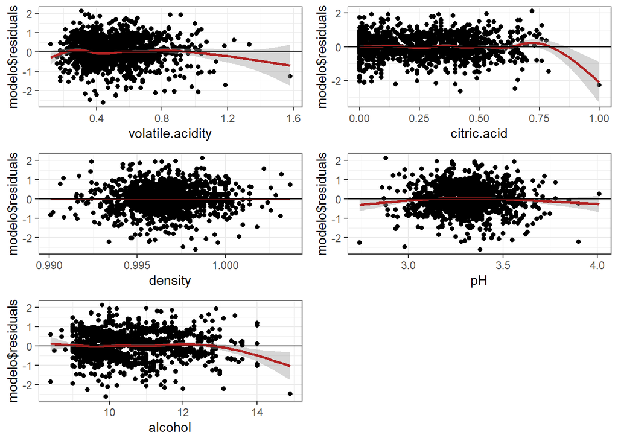

```r
plot1 <- ggplot(data = wineData, aes(volatile.acidity, modelo$residuals)) +
    geom_point() + geom_smooth(color = "firebrick") + geom_hline(yintercept = 0) +
    theme_bw()
plot2 <- ggplot(data = wineData, aes(citric.acid, modelo$residuals)) +
    geom_point() + geom_smooth(color = "firebrick") + geom_hline(yintercept = 0) +
    theme_bw()
plot3 <- ggplot(data = wineData, aes(density, modelo$residuals)) +
    geom_point() + geom_smooth(color = "firebrick") + geom_hline(yintercept = 0) +
    theme_bw()
plot4 <- ggplot(data = wineData, aes(pH, modelo$residuals)) +
    geom_point() + geom_smooth(color = "firebrick") + geom_hline(yintercept = 0) +
    theme_bw()
plot5 <- ggplot(data = wineData, aes(alcohol, modelo$residuals)) +
    geom_point() + geom_smooth(color = "firebrick") + geom_hline(yintercept = 0) +
    theme_bw()
grid.arrange(plot1, plot2, plot3, plot4, plot5)
```